# DSO 545: HW 3 (Due March 31)

1. Question 1

Although many paths may lead to the Presidency of the United States, but what is the most common job experience, occupation or profession of U.S. presidents, home state at the time of election to the Presidency? A table that can be downloaded from internet (see **https://en.wikipedia.org/wiki/List_of_Presidents_of_the_United_States_by_previous_experience**) which enumerates all holders of the presidence office, along with major elective or appointive offices or periods of military service prior to election to the Presidency, occupation, and their home state. The column immediately to the right of the Presidents’ names shows the position or office held just before the Presidency. The next column to the right lists the next previous position held, and so on. Note that the total number of previous positions held by an individual may exceed four. The last two columns list primary occupation of each future President, prior to beginning a political career and the home state at the time of election to the Presidency respectively.

**Instructions:** Create a US map with state borders. Count how many presidents are from each state (home states). Using colors (low=white and high=darkred) to indicate the total number of presidents from each state (white color means zero). In addition to colors, add numbers to the graph that represent the total number of presidents whose home state was that state at the time of election to the Presidency respectively.

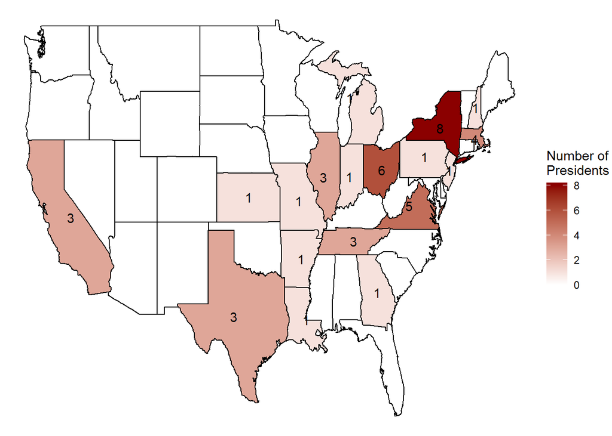

### Use the following to answer questions 2- 4:

Forecasting transportation demand is important for multiple purposes such as staffing, planning, and inventory control. The public transportation system in Santiago de Chile has gone through a major effort of reconstruction. In this context, a business intelligence competition took place in October 2006, which focused on forecasting demand for public transportation. This case is based on the competition, with some modifications.

A public transportation company is expecting an increase in demand for its services and is planning to acquire new buses and to extend its terminals. These investments require a reliable forecast of future demand. To create such forecasts, one can use data on historic demand. The company’s data warehouse has data on each 15-minute interval between 6:30 and 22:00, on the number of passengers arriving at the terminal. As a member of a forecasting consultants team, you have been asked to visualize data to help experts of forecasting models to forecasting method that can generate forecasts for the number of passengers arriving at the terminal.

2. Question 2

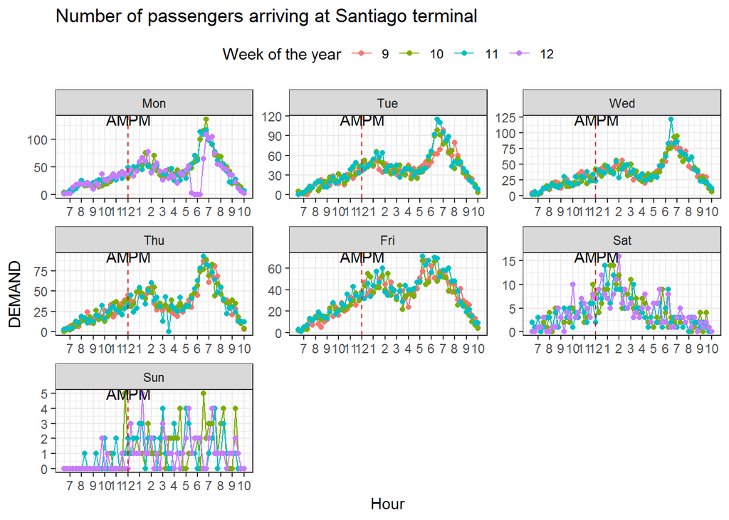

3. Question 3

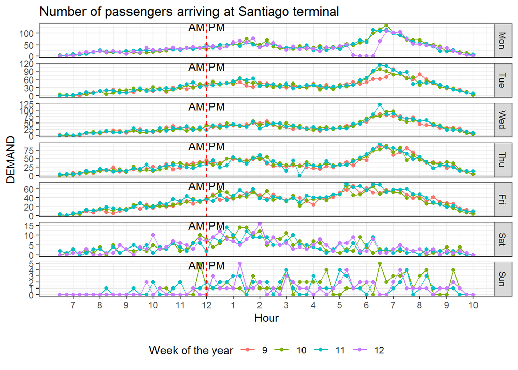

4. Question 4

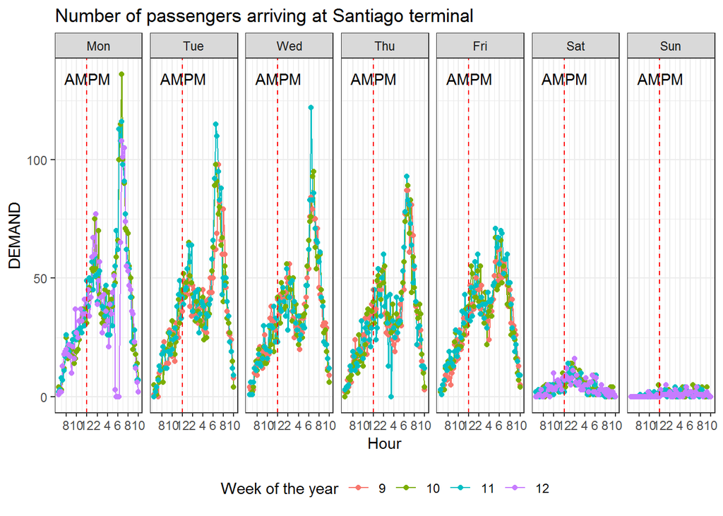

FlightDelays.csv contains flight ( from DC to NYC in January of 2014). Create a heat map of percent of delayed flights by day of aweek, origin, and carrier.

5. Question 5

```
##  [1] "CRS_DEP_TIME"  "CARRIER"       "DEP_TIME"      "DEST"
##  [5] "DISTANCE"      "FL_DATE"       "FL_NUM"        "ORIGIN"
##  [9] "Weather"       "DAY_WEEK"      "DAY_OF_MONTH"  "TAIL_NUM"
## [13] "Flight.Status"
```

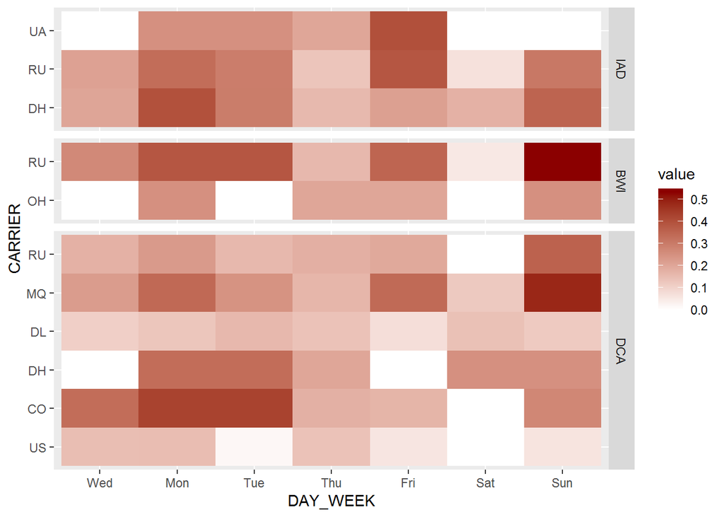